# Deep Learning

## (b) update weights

**By using your code in `1(a)`, update weight parameters from 1 iteration of forward and backpropagation.**

Updated parameters were stored in the `wei` list. So we can derive updated weights from 1 iteration of forward and backpropagation by `wei[[1]]`. There are some changes in weight parameters compare to the initial values.

updated weights from the first iteration of forward and backward propagation

|  | W1 | W2 | W3 | W4 | W5 | W6 | W7 | W8 |
| --- | --- | --- | --- | --- | --- | --- | --- | --- |
| given | 0.15 | 0.2 | 0.25 | 0.3 | 0.4 | 0.45 | 0.5 | 0.55 |
| 1st | 0.1497807 | 0.1995614 | 0.2497511 | 0.2995023 | 0.3589165 | 0.4086662 | 0.5113013 | 0.5613701 |

## (c) different learning rates

**Try 3 different learning rates($\gamma$ = 0.1, $\gamma$ = 0.6, $\gamma$ = 1.2), and repeat forward/back propagation 10,000 iterations. Draw error rate figure, and calculate prediction results as in the page 37-38 of the DL08 slide. Discuss about the convergence of neural network fittings based on different learning rates.**

For different learning rates, we can set the `gamma` parameter differently in the code. And for different iteration number, we can apply `iteration = 10000` function.

### error rate fig

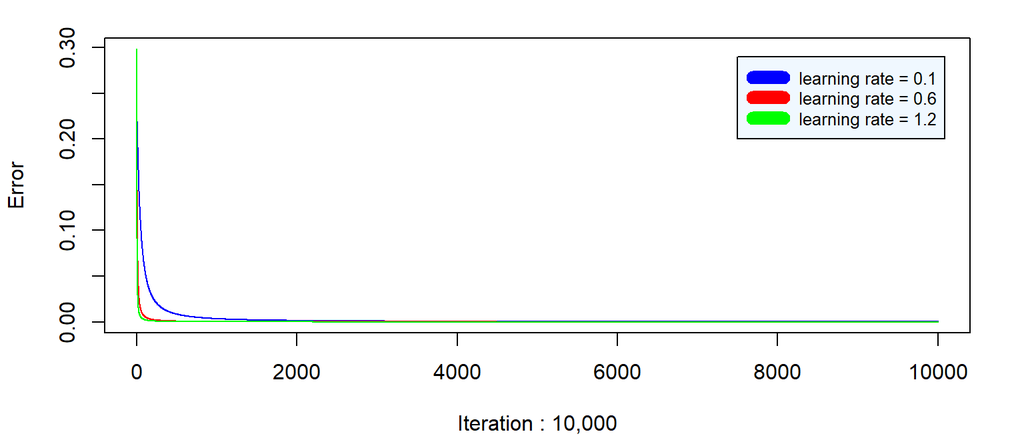

```r
par(mar=c(4.5, 4.1, 1.5, 2.1))
plot(1:iteration, err1, col="blue", type="l", lty=1, ylab="Error", xlab = "Iteration : 10,000")
lines(1:iteration, err2, col="red")
lines(1:iteration, err3, col="green")

sub = c("learning rate = 0.1", "learning rate = 0.6", "learning rate = 1.2")
legend(7500, 0.29, legend = sub, col=c("blue","red","green"), lty=1, cex=0.8, bg='aliceblue', lwd=10)
```

### prediction results

To get differently predicted values through different learning rates, `output` lists were used. `output1`, `output2` and `output3` lists represent **0.1**, **0.6** and **1.2** rates respectively.

```r
ans = matrix(cbind(output1[[iteration]], output2[[iteration]], output3[[iteration]], t(matrix(out))),2)
```

Table: Prediction results with varying with 10,000 iterations.

|  | learning rate = 0.1 | learning rate = 0.6 | learning rate = 1.2 | True Values |
| --- | --- | --- | --- | --- |
| out1 | 0.0217111 | 0.0117727 | 0.0104678 | 0.01 |
| out2 | 0.9784156 | 0.9882453 | 0.9895359 | 0.99 |

### convergence

Most of the errors become similar at the very left side of the plot. As a result, the differences in the errors of the different learning rates are compressed, making these differences more difficult to judge.

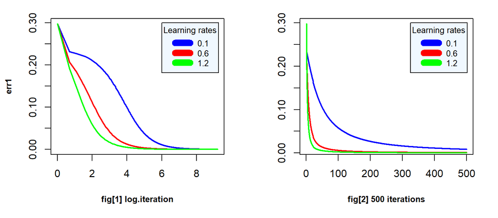

Although, every errors from three different learning rate parameters converged well as iteration goes on, it seems obvious that the larger parameters a model has, the better it is.

Also, It can be shown in the previous prediction results too. Although, every three models make prediction well compared to the true values, 0.01, 0.99, it has the closest prediction when model uses the largest learning rate, $\gamma=1.2$, among them.

This is clear, considering the fact that the more iterations are performed, the more precise parameters become and the larger step size usually helps for the model to move quickly, which makes similar effects on the convergence as the large number of iterations do.

However, It does not mean that always larger step size or learning rate is a good hyeprparameter for models. Too large learning rate can cause the model to converge too quickly to a suboptimal solution, whereas a learning rate that is too small can cause the process to get stuck. Therefore, carefully selecting the learning rate is one of the most important thing in the neural network.

# 2. perceptron

**Based on the DL09 slide uploaded in the yscec, we will do studies for implementing a linear separable classifier (perceptron) for the iris data set.**

## (a) complete the code

Complete perceptron code for classifying setosa and Virginica based on the DL09 slide.

### Description

Here only 2 different species,`setosa & Virginica`, in the iris data set will be used and `sepal & petal` length will be the observed values to distinguish between them. Below is a scatter plot showing that setosa and Virginica can be distinguished by a single linear equation.

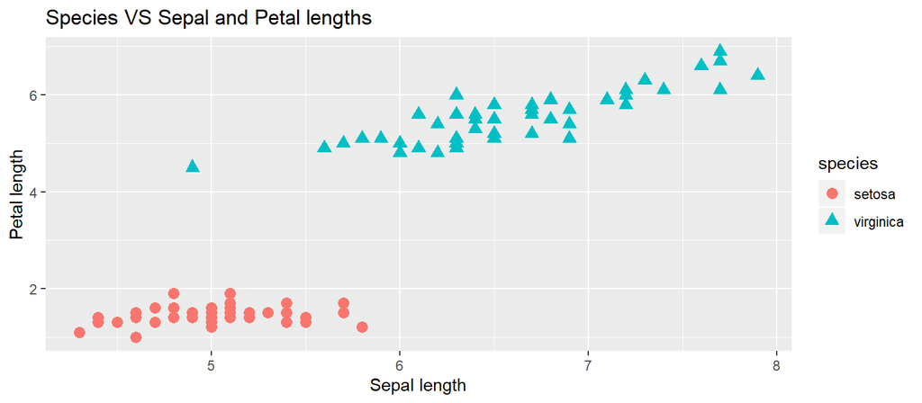

setosa and Virginica can be split by a straight line

### Initalization

Required data is as follows.

```r
data(iris)
iris_sub = iris[-c(51:100), c(1,3,5)]
names(iris_sub) = c("sepal", "petal", "species")

x = iris_sub[, c(1,2)]
y = ifelse(iris_sub[,3] == 'setosa', 1, -1)
```

Initalize weights, bias and `k` parameters. `k` value is to count updates.

```r
w = c(0,0)
b = 0
k = 0
```

Set learning rate to 0.5.

```r
learning.rate = 0.5
```

### Functions

To distinguish between setosa and Virginica, the sign of $w_1*(Sepal\quad length)+w_2*(Petal\quad length)$d will be used.

```r
distance.from.plane = function(z,w,b){sum(z*w)+b}

classify.linear = function(x,w,b){
    distances = apply(x, 1, distance.from.plane, w, b)
    return(ifelse(distances <0, -1, +1))}
```

Also, to update bias parmeter, `b`, $max(||x_i||)$ will be used.

```r
euclidean.norm = function(x) {sqrt(sum(x * x))}
```

Therefore, the `perception` function is defined as follows.

```r
perceptron = function(x, y, learning.rate){
    w = c(0,0)
    b = 0
    k = 0
    R = max(apply(x, 1, euclidean.norm))
    mark.complete = TRUE

    while (mark.complete) {
        mark.complete = FALSE
        yc = classify.linear(x,w,b)
        for (i in 1:nrow(x)) {
            if (y[i] != yc[i]) {
                w = w + learning.rate * y[i] * x[i,]
                b = b + learning.rate * y[i] * R^2
                k = k+1
                mark.complete=TRUE
            }
        }
    }
    return(list(w,b,k))
}
```

### Full code

```r
data(iris)
iris_sub = iris[-c(51:100), c(1,3,5)]
names(iris_sub) = c("sepal", "petal", "species")

x = iris_sub[, c(1,2)]
y = ifelse(iris_sub[,3] == 'setosa', -1, 1)
learning.rate = 0.5

euclidean.norm = function(x) {sqrt(sum(x * x))}
distance.from.plane = function(z,w,b){sum(z*w)+b}
classify.linear = function(x,w,b){
    distances = apply(x, 1, distance.from.plane, w, b)
    return(ifelse(distances <0, -1, +1))}

perceptron = function(x, y, learning.rate){
    w = c(0,0)
    b = 0
    k = 0
    R = max(apply(x, 1, euclidean.norm))
    mark.complete = TRUE

    while (mark.complete) {
        mark.complete = FALSE
        yc = classify.linear(x,w,b)
        for (i in 1:nrow(x)) {
            if (y[i] != yc[i]) {
                w = w + learning.rate * y[i] * x[i,]
                b = b + learning.rate * y[i] * R^2
                k = k+1
                mark.complete=TRUE
            }
        }
    }
    return(list(w,b,k))
}

results = perceptron(x, y, learning.rate)
```

## (b) Report results

Report your estimated weight and bias parameters. How many iterations are required for your update?

```
## [[1]]
##    sepal petal
## 1 124.85 516.9
##
## [[2]]
## [1] -1710.4
##
## [[3]]
## [1] 568
```

| sepal | petal | bias | iterations |
| --- | --- | --- | --- |
| 124.85 | 516.9 | -1710.4 | 568 |

## (c) Draw linear classifier

Draw your linear classifier for setosa and Virginica as in the page 18 of the DL09 slide.

linear classifier :
$$b + w_1x_1 + w_2x_2 = 0$$

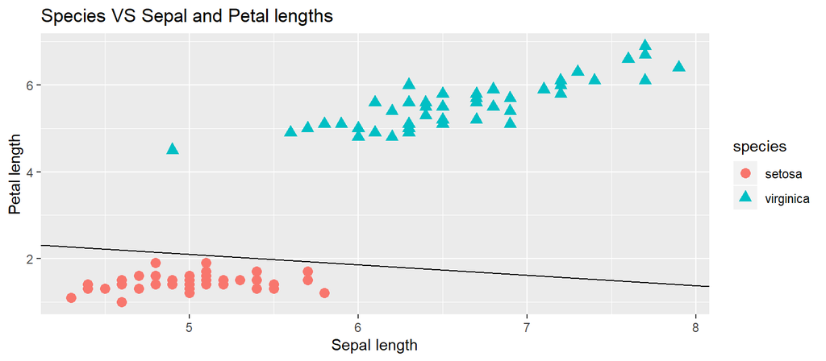

setosa and Virginica can be split by a straight line

```r
par(mar=c(6, 4.1, 3, 2.1))
p <- ggplot(iris_sub, aes(x=sepal, y=petal))+
    geom_point(aes(colour = species, shape = species), size = 3) +
    xlab("Sepal length") +
    ylab("Petal length") +
    ggtitle("Species VS Sepal and Petal lengths")
p+geom_abline(intercept=unlist(-results[[2]]/results[[1]][2]), slope=unlist(-results[[1]][1]/results[[1]][2]))
```

이해환 2014121199

2019-10-26